# HW9_Porter_Erica

Below I just recreated the simple.py example to figure out how the file inputs work.

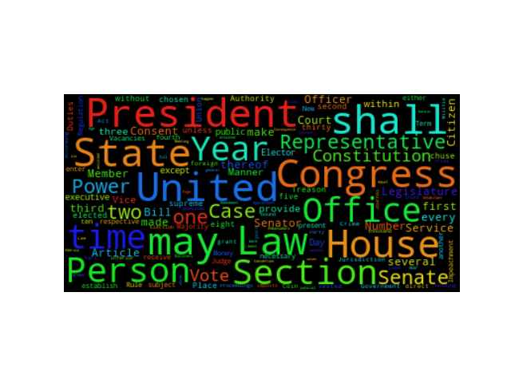

Some notes/remarks about the changes/installation:

- I specified the engine path to be used, in case some libraries were installed under Python 2.7.
- I specified ‘python’ in the display options above each code chunk instead of ‘r,’ to let R know to use my Python interprete in order to run Python code.
- I downloaded and moved all files necessary to generate the word cloud to the directory that houses my homework file and is connected to my Git repository.
- I also had to reset my working directory appropriately, as I had unknowingly switched to another directory when working on regression homework.
- The original code from Andreas Mueller’s repository included code to create and open the word cloud as an image, rather than include it in an html document. So, the constitution.txt example (from the lecture slides), uses $\texttt{plt.savefig}$ and the alice.txt example uses $\texttt{wc.to_file}$ and then a $\texttt{knitr}$ statement to include the picture in the knitted html document.
- The given code from https://github.com/amueller/word_cloud/blob/master/examples/masked.py creates an object for the alice.txt document, creates a color array, removes one stop word, plots a word cloud over the image of Alice, and writes the word cloud to an object that we can print/view.

[figure not shown]

Code, files, and images obtained from the following Github repository:

Mueller, Andreas, amueller/word_cloud, 3 Sept. 2017, GitHub repository, github.com/amueller/word_cloud/tree/master/examples

# Appendix: replicated code from amueller/word_cloud

```r
from os import path
from wordcloud import WordCloud
import matplotlib.pyplot as plt

text = open('constitution.txt').read()

wordcloud = WordCloud().generate(text)

plt.imshow(wordcloud, interpolation='bilinear')
plt.axis("off")

wordcloud = WordCloud(max_font_size = 40).generate(text)
plt.figure()
plt.imshow(wordcloud, interpolation = "bilinear")
plt.axis("off")

plt.savefig("constitution.png")
    knitr::include_graphics("constitution.png")

from os import path
from PIL import Image
import numpy as np
import matplotlib.pyplot as plt

from wordcloud import WordCloud, STOPWORDS, ImageColorGenerator

# Read the whole text for "Alice's Adventures in Wonderland" this time
text = open('alice.txt').read()

# read the image to be used as a mask
# the image of Alice taken from http://jirkavinse.deviantart.com/art/quot-Real-Life-quot-Alice-282261010
alice_coloring = np.array(Image.open("alice_color.png"))
stopwords = set(STOPWORDS)
stopwords.add("said")

wc = WordCloud(background_color = "white", max_words = 2000, mask = alice_coloring,
               stopwords = stopwords, max_font_size = 40, random_state = 42)

# generate word cloud
wc.generate(text)

wc.to_file("alice.png")

# create coloring from image
image_colors = ImageColorGenerator(alice_coloring)
    knitr::include_graphics("alice.png")
```